# EP06-avance1-equipo-03.Rmd

2026-10-29

### Contexto

Hasta ahora hemos inferido sobre medias y proporciones con pruebas que se apoyan en el modelo normal. Con las proporciones, cuando sus condiciones no se cumplían, recurrimos a pruebas no paramétricas para frecuencias, como la exacta de Fisher o la de McNemar. Con variables numéricas pasa algo parecido: muchas veces la variable que nos interesa se carga hacia un lado, tiene valores muy extremos o está acotada, y las pruebas para medias dejan de ser confiables.

Para esos casos, la lectura 7 propone dos caminos: transformar los datos para que sí cumplan las condiciones, y aplicar la prueba paramétrica en la nueva escala, o usar una prueba basada en rangos (la de suma de rangos o la de rangos con signo de Wilcoxon, la de Kruskal-Wallis o la de Friedman), que no supone normalidad pero contrasta otras hipótesis. Cuál corresponde depende de los datos y de lo que interesa saber.

#### Pregunta 1

Considerando las instancias con 60 o más nodos, ¿hay diferencias entre los tiempos de ejecución de las versiones A, B y C del algoritmo? Con la semilla 300, saquen 13 instancias para la versión A, 15 instancias para la versión B y 12 instancias para la versión C, todas distintas (muestras independientes). Si sacaron bien la muestra, deberían obtener: A, n = 13 y media 1.379.668; B, n = 15 y media 1.711.541; C, n = 12 y media 919.543,1 [ms].

### Qué prueba vamos a usar

ANOVA de 1 vía para muestras independientes dado que hay 3 grupos (A, B y C) y se asume que las muestras son independientes.

### Condiciones

- **Independencia:** Las muestras son independientes porque son distintas y se obtuvieron aleatoriamente y separadas.
- **Normalidad:** La población sigue una distribución normal.
- **Homocedasticidad:** Las muestras tienen la misma varianza.

##### Comprobación de condiciones de Anova

```r
datos <- read.csv("EP06 Datos.csv")

# Filtrar instancias con 60 o más nodos
datos_p1_filtrados <- datos %>% filter(n.nodos >= 60)

# Muestreo con semilla 300 (40 instancias distintas en total)
set.seed(300)
instancias <- sample(datos_p1_filtrados$instancia, 13 + 15 + 12, replace = FALSE)

inst_A <- instancias[1:13]
inst_B <- instancias[14:28]
inst_C <- instancias[29:40]

# Construir muestras independientes para cada versión del algoritmo
muestra_A <- datos_p1_filtrados %>%
  filter(instancia %in% inst_A) %>%
  select(instancia, tiempo = tiempo.A) %>%
  mutate(algoritmo = "A")

muestra_B <- datos_p1_filtrados %>%
  filter(instancia %in% inst_B) %>%
  select(instancia, tiempo = tiempo.B) %>%
  mutate(algoritmo = "B")

muestra_C <- datos_p1_filtrados %>%
  filter(instancia %in% inst_C) %>%
  select(instancia, tiempo = tiempo.C) %>%
  mutate(algoritmo = "C")

# Unir muestras en formato tidy
datos_p1 <- bind_rows(muestra_A, muestra_B, muestra_C) %>%
  mutate(algoritmo = as.factor(algoritmo))

# Verificación según valores de control del enunciado
datos_p1 %>%
  group_by(algoritmo) %>%
  summarise(
    n = n(),
    media = round(mean(tiempo), 1)
  )
```

```
## # A tibble: 3 × 3
##   algoritmo     n    media
##   <fct>     <int>    <dbl>
## 1 A            13 1379668.
## 2 B            15 1711541.
## 3 C            12  919543.
```

```r
# Prueba de normalidad con Shapiro-Wilk por algoritmo
shapiro_A <- shapiro.test(datos_p1$tiempo[datos_p1$algoritmo == "A"])
shapiro_B <- shapiro.test(datos_p1$tiempo[datos_p1$algoritmo == "B"])
shapiro_C <- shapiro.test(datos_p1$tiempo[datos_p1$algoritmo == "C"])

# Prueba de homocedasticidad con Levene
pru_levene <- LeveneTest(tiempo ~ algoritmo, data = datos_p1, center = median)

# Mostrar resultados
cat("=== Prueba de normalidad (Shapiro-Wilk) ===\n")
```

```
## === Prueba de normalidad (Shapiro-Wilk) ===
```

```r
print(shapiro_A)
```

```
##
##  Shapiro-Wilk normality test
##
## data:  datos_p1$tiempo[datos_p1$algoritmo == "A"]
## W = 0.85425, p-value = 0.03237
```

```r
print(shapiro_B)
```

```
##
##  Shapiro-Wilk normality test
##
## data:  datos_p1$tiempo[datos_p1$algoritmo == "B"]
## W = 0.88634, p-value = 0.05906
```

```r
print(shapiro_C)
```

```
##
##  Shapiro-Wilk normality test
##
## data:  datos_p1$tiempo[datos_p1$algoritmo == "C"]
## W = 0.84047, p-value = 0.02805
```

```r
cat("\n=== Prueba de homocedasticidad (Levene) ===\n")
```

```
##
## === Prueba de homocedasticidad (Levene) ===
```

```r
print(pru_levene)
```

```
## Levene's Test for Homogeneity of Variance (center = median)
##       Df F value Pr(>F)
## group  2  1.0625 0.3559
##       37
```

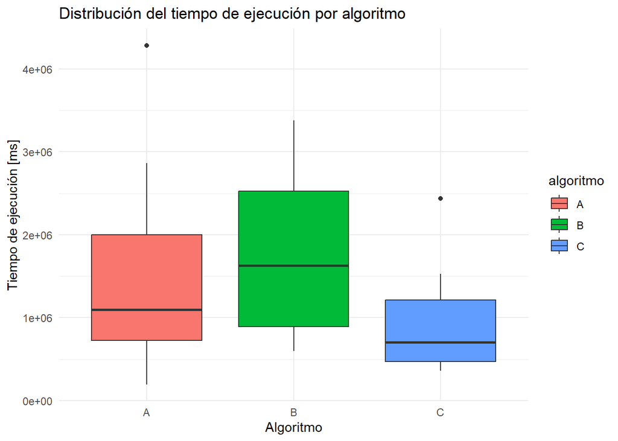

```r
# Gráficos para visualizar distribuciones
library(ggplot2)
ggplot(datos_p1, aes(x = algoritmo, y = tiempo, fill = algoritmo)) +
  geom_boxplot() +
  labs(
    title = "Distribución del tiempo de ejecución por algoritmo",
    x = "Algoritmo", y = "Tiempo de ejecución [ms]"
  ) +
  theme_minimal()
```

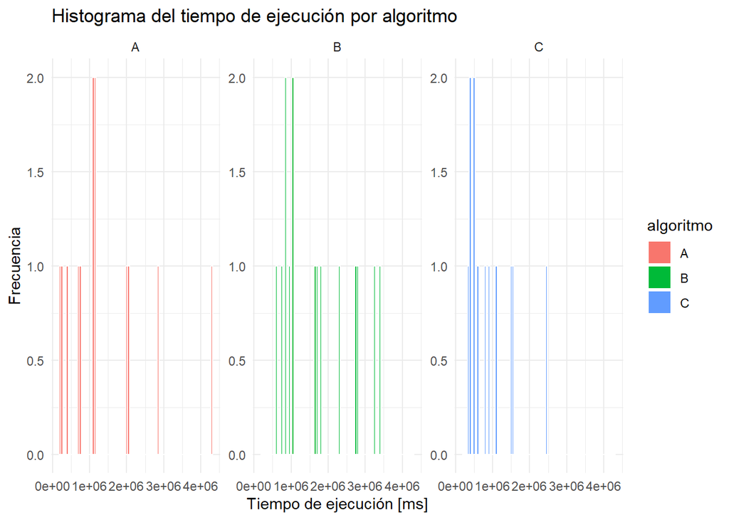

```r
ggplot(datos_p1, aes(x = tiempo, fill = algoritmo)) +
  geom_histogram(binwidth = 50000, color = "white") +
  facet_wrap(~algoritmo, scales = "free_y") +
  labs(
    title = "Histograma del tiempo de ejecución por algoritmo",
    x = "Tiempo de ejecución [ms]", y = "Frecuencia"
  ) +
  theme_minimal()
```

#### Pregunta 2

Considerando las instancias con 90 o más nodos, ¿hay diferencias entre los tiempos de ejecución de las versiones B y C del algoritmo? Con la semilla 660, saquen 24 instancias para la versión B y 21 instancias para la versión C, todas distintas (muestras independientes). Si sacaron bien la muestra, deberían obtener: B, n = 24 y media 2.595.205; C, n = 21 y media 1.389.397 [ms].

### Qué prueba vamos a usar

t de student dado que solo hay 2 grupos y que las muestras son independientes.

### Condiciones

- **Independencia:** Las muestras son independientes porque son distintas y se obtuvieron aleatoriamente y separadas.
- **Normalidad:** La población sigue una distribución normal.
- **Homocedasticidad:** Las muestras tienen la misma varianza

```r
# Filtrar instancias con 90 o más nodos
datos_p2_filtrados <- datos %>% filter(n.nodos >= 90)

# Muestreo con semilla 660 (45 instancias distintas en total)
set.seed(660)
instancias <- sample(datos_p2_filtrados$instancia, 24 + 21, replace = FALSE)

inst_B <- instancias[1:24]
inst_C <- instancias[25:45]

# Construir muestras independientes para cada versión del algoritmo
muestra_B <- datos_p2_filtrados %>%
  filter(instancia %in% inst_B) %>%
  select(instancia, tiempo = tiempo.B) %>%
  mutate(algoritmo = "B")

muestra_C <- datos_p2_filtrados %>%
  filter(instancia %in% inst_C) %>%
  select(instancia, tiempo = tiempo.C) %>%
  mutate(algoritmo = "C")

# Unir muestras en formato tidy
datos_p2 <- bind_rows(muestra_B, muestra_C) %>%
  mutate(algoritmo = as.factor(algoritmo))

# Verificación según valores de control del enunciado
datos_p2 %>%
  group_by(algoritmo) %>%
  summarise(
    n = n(),
    media = round(mean(tiempo), 1)
  )
```

```
## # A tibble: 2 × 3
##   algoritmo     n    media
##   <fct>     <int>    <dbl>
## 1 B            24 2595205.
## 2 C            21 1389397.
```

```r
# Prueba de normalidad con Shapiro-Wilk por algoritmo
shapiro_B <- shapiro.test(datos_p2$tiempo[datos_p2$algoritmo == "B"])
shapiro_C <- shapiro.test(datos_p2$tiempo[datos_p2$algoritmo == "C"])

# Prueba de homocedasticidad con Levene
pru_levene <- LeveneTest(tiempo ~ algoritmo, data = datos_p2, center = median)

# Mostrar resultados
cat("=== Prueba de normalidad (Shapiro-Wilk) ===\n")
```

```
## === Prueba de normalidad (Shapiro-Wilk) ===
```

```r
print(shapiro_B)
```

```
##
##  Shapiro-Wilk normality test
##
## data:  datos_p2$tiempo[datos_p2$algoritmo == "B"]
## W = 0.97385, p-value = 0.7618
```

```r
print(shapiro_C)
```

```
##
##  Shapiro-Wilk normality test
##
## data:  datos_p2$tiempo[datos_p2$algoritmo == "C"]
## W = 0.86869, p-value = 0.009072
```

```r
cat("\n=== Prueba de homocedasticidad (Levene) ===\n")
```

```
##
## === Prueba de homocedasticidad (Levene) ===
```

```r
print(pru_levene)
```

```
## Levene's Test for Homogeneity of Variance (center = median)
##       Df F value  Pr(>F)
## group  1  3.3967 0.07223 .
##       43
## ---
## Signif. codes:  0 '***' 0.001 '**' 0.01 '*' 0.05 '.' 0.1 ' ' 1
```

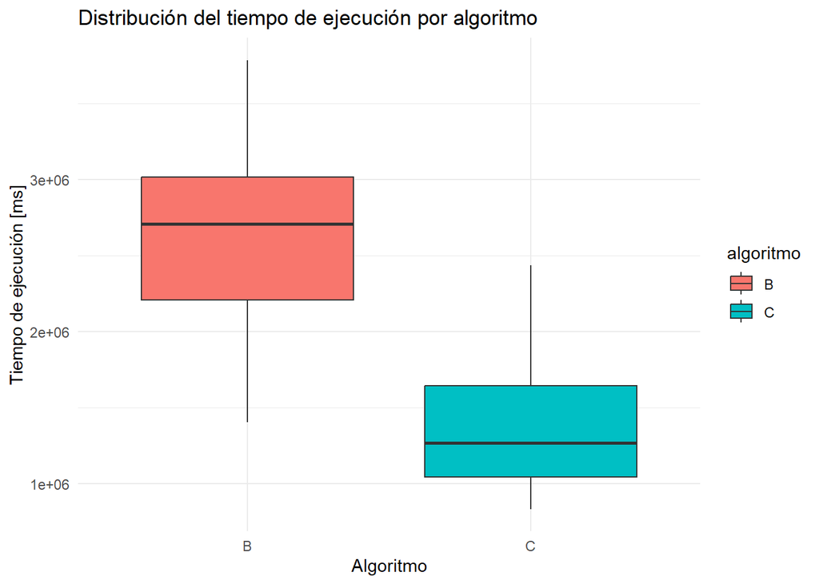

```r
# Gráficos para visualizar distribuciones
library(ggplot2)
ggplot(datos_p2, aes(x = algoritmo, y = tiempo, fill = algoritmo)) +
  geom_boxplot() +
  labs(
    title = "Distribución del tiempo de ejecución por algoritmo",
    x = "Algoritmo", y = "Tiempo de ejecución [ms]"
  ) +
  theme_minimal()
```

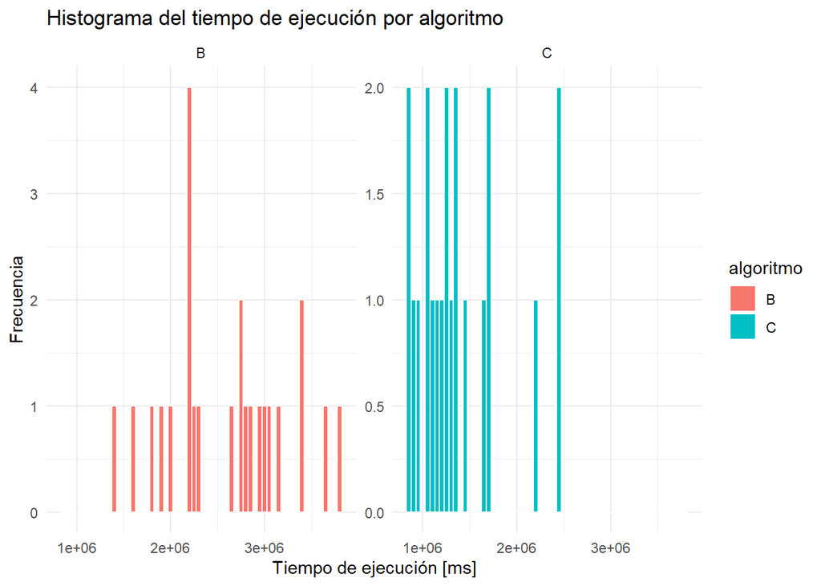

```r
ggplot(datos_p2, aes(x = tiempo, fill = algoritmo)) +
  geom_histogram(binwidth = 50000, color = "white") +
  facet_wrap(~algoritmo, scales = "free_y") +
  labs(
    title = "Histograma del tiempo de ejecución por algoritmo",
    x = "Tiempo de ejecución [ms]", y = "Frecuencia"
  ) +
  theme_minimal()
```

#### Pregunta 3

Considerando las instancias con 60 o más nodos, ¿hay diferencias entre los tiempos de ejecución de las versiones A y B del algoritmo? Con la semilla 781, saquen 15 instancias para la versión A y 14 instancias para la versión B, todas distintas (muestras independientes). Si sacaron bien la muestra, deberían obtener: A, n = 15 y media 1.338.905; B, n = 14 y media 2.063.490 [ms].

### Qué prueba vamos a usar

t de student dado que solo hay 2 grupos y que las muestras son independientes.

### Condiciones

#### Pregunta 5

Considerando las instancias con 80 o más nodos, ¿hay diferencias entre los tiempos de ejecución de las versiones A, B y C del algoritmo? Con la semilla 869, saquen 16 instancias para la versión A, 13 instancias para la versión B y 15 instancias para la versión C, todas distintas (muestras independientes). Si sacaron bien la muestra, deberían obtener: A, n = 16 y media 1.766.128; B, n = 13 y media 2.309.595; C, n = 15 y media 1.260.024 [ms].

### Qué prueba vamos a usar

ANOVA de 1 vía para muestras independientes dado que hay 3 grupos y que las muestras son independientes.

### Condiciones

- **Independencia:** Las muestras son independientes porque son distintas y se obtuvieron aleatoriamente y separadas.
- **Normalidad:** La población sigue una distribución normal.
- **Homocedasticidad:** Las muestras tienen la misma varianza

#### Pregunta 6

Considerando las instancias con 50 o más nodos, ¿hay diferencias entre las mejores soluciones que encuentran las versiones A, B y C del algoritmo cuando resuelven las mismas instancias? Con la semilla 351, saquen 19 instancias y usen sus resultados con las tres versiones. Si sacaron bien la muestra, deberían obtener: n = 19; A, media 97,941; B, media 95,912; C, media 97,415 [% del óptimo].